# Baldwin

```python
import IPython.core.display as di

# This line will hide code by default when the notebook is exported as HTML
di.display_html('<script>jQuery(function() {if (jQuery("body.notebook_app").length == 0) { jQuery(".input_area").toggle(); jQuery(".prompt").toggle();}});</script>', raw=True)
```

The objective is to find abnormal behaviour when the pump was running normally.

The steps followed in the process are as follows:

1. Exploratory Data Analysis. a) Number of datapoints b) DataType of column c) Duration of pump running dataset d) Distribution of values in each column(features) e) Proportion of null values in each cloumn
2. Imputing null values using KNNImpute and Data scaling using StandardScaler (z scaling)
3. Trained dataset on 3 different algorithms namely PCA + Mahalanobis Distance, KMeans, Autoencoder
4. Aggregated the prediction from different algorithm to have less number False alarms.

As a result in the training set there are 8 anomalies and in test set there are 10 anomalies from days 23rd May, 26th May, 27th May, 7th June, 8th June and 9th June.

```python
import pandas as pd
import numpy as np
import lib as l
import warnings
warnings.simplefilter("ignore")
import math
import statsmodels.api as sm
from statsmodels.stats.outliers_influence import variance_inflation_factor
from sklearn.metrics.pairwise import cosine_similarity
import seaborn as sns
import matplotlib.pyplot as plt
from mpl_toolkits.mplot3d import Axes3D
from sklearn.preprocessing import StandardScaler
from sklearn.model_selection import train_test_split

#from fancyimpute import KNN
from datetime import timedelta
from sklearn.cluster import KMeans
from pyod.models.auto_encoder import AutoEncoder
from sklearn.impute import KNNImputer
from sklearn.decomposition import PCA
from sklearn.neighbors import NearestNeighbors
import scipy as sp
import scipy.linalg as la
from sklearn.cluster import DBSCAN
#interactive plots
%matplotlib notebook
```

```python
###### Cluster Profiling ############

def Cluster_Profiling(df, ClustureName):
    cluster_avg = df.groupby(ClustureName).mean()
    cluster_std = df.groupby(ClustureName).std()
    population_avg = df.mean()
    # Calculate relative importance of cluster's attribute value compared to population
    relative_imp = ((cluster_avg - population_avg)/ cluster_std).round(2)

    # Initialize a plot with a figure size of 8 by 2 inches
    #plt.figure(figsize=(20, 12))
    #plt.title('Relative importance of attributes')

    # Plot the heatmap
    #sns.heatmap(data=relative_imp, annot=True, fmt='.2f', cmap='RdYlGn')
    #plt.show()
    return relative_imp




## distance of population mean with clusters
def cluster_diff(df, num_clusters, ClustureName):
    print("Number of points in each cluster\n{}\n\n".format(df.groupby(ClustureName).size()))
    print("Distance of population mean with clusters")
    population_avg = df.mean()
    pop_md_from_clusters = {}
    for i in range(num_clusters):
        ED = np.linalg.norm(population_avg-df[df[ClustureName] == i].mean())
        cos= 1-cosine_similarity(population_avg.values.reshape(1,-1), df[df[ClustureName] == i].mean().values.reshape(1,-1))[0][0]
        pop_md_from_clusters['C'+str(i)]= [ED.round(2), cos.round(2)]
        print("C{}: {}".format(i,pop_md_from_clusters['C'+str(i)]))
    return
```

# Read CSV file into DataFrame

```python
# read file
file_name = 'baldwin_pump_data.csv'

df = pd.read_csv(file_name, parse_dates = True, index_col = 0)
```

```python
df.head()
```

|  | BFP_SEAL_WATER_FLOW | BFP_SUCT_HDR_PRESS________ | AUX_CDSR_2B_PRESS_________ | BFP_SUCTION_HDR_TEMP______ | BFPT_B_VALVE_DEMAND_HP_STO | BFPT_B_VALVE_DEMAND_LP_STO | BFPT_B_CALC_VALVE_DEMAND__ | 2B_TDBFP_RECIRC_VLV_DMD___ | BFP_2B_DISCHARGE_FLOW_____ | BFP_2B_IBRD_SEAL_INJ_FLOW_ | ... | BFPT_2B_RAD_SHAFT_VIB_IB_B | BFP_2B_AXIAL_SHAFT_VIB____ | BFPT_2B_THRUST_BRG_WEAR___ | BFP_2B_RAD_SHAFT_VIB_OB_BR | BFP_2B_RAD_SHAFT_VIB_IB_BR | BFPT_2B_AXIAL_SHAFT_VIB___ | MAIN_STEAM_FLOW_TO_BFPS___ | EXT_STM_FLOW_TO_BFP_2B____ | CW_FRM_AUX_CDSR_2B________ | CW_TO_AUX_CDS_2B |
| --- | --- | --- | --- | --- | --- | --- | --- | --- | --- | --- | --- | --- | --- | --- | --- | --- | --- | --- | --- | --- | --- |
| 1998-05-01 00:00:00 | 14.35 | 136.18 | 29.2 | 88.57 | 0.01 | 0.0 | 0.0 | 99.98 | 0.0 | 25.44 | ... | NaN | NaN | NaN | NaN | NaN | NaN | 0.0 | NaN | 68.11 | 65.72 |
| 1998-05-01 00:05:00 | 14.35 | 136.18 | 29.2 | 88.57 | 0.01 | 0.0 | 0.0 | 99.98 | 0.0 | 25.44 | ... | NaN | NaN | NaN | NaN | NaN | NaN | 0.0 | NaN | 68.11 | 65.72 |
| 1998-05-01 00:10:00 | 14.35 | 136.18 | 29.2 | 88.57 | 0.01 | 0.0 | 0.0 | 99.98 | 0.0 | 25.44 | ... | NaN | NaN | NaN | NaN | NaN | NaN | 0.0 | NaN | 68.11 | 65.72 |
| 1998-05-01 00:15:00 | 14.35 | 136.18 | 29.2 | 88.57 | 0.01 | 0.0 | 0.0 | 99.98 | 0.0 | 25.44 | ... | NaN | NaN | NaN | NaN | NaN | NaN | 0.0 | NaN | 68.11 | 65.72 |
| 1998-05-01 00:20:00 | 14.34 | 136.18 | 29.2 | 88.57 | 0.01 | 0.0 | 0.0 | 99.98 | 0.0 | 25.44 | ... | NaN | NaN | NaN | NaN | NaN | NaN | 0.0 | NaN | 68.11 | 65.72 |

5 rows × 47 columns

# Number of records by Month and week

```python
# count of data by month and week
df.groupby([df.index.month, df.index.week]).size().rename_axis(index=['month','week'])
```

```
month  week
5      18       864
       19      2016
       20      2016
       21      2016
       22      2016
6      23      2016
       24      1717
dtype: int64
```

# Proportion of Null values by columns

```python
# null values
df_null = l.proportion_null_values(df)
df_null
```

|  | NonNull_Count | Null-Count | Null_Proportion | Null_Proportion_after_dropoing_rows_with_all_null |
| --- | --- | --- | --- | --- |
| BFP_SEAL_WATER_FLOW | 12646 | 15 | 0.12 | 0.02 |
| BFP_SUCT_HDR_PRESS________ | 8547 | 4114 | 32.49 | 32.40 |
| AUX_CDSR_2B_PRESS_________ | 12646 | 15 | 0.12 | 0.02 |
| BFP_SUCTION_HDR_TEMP______ | 12649 | 12 | 0.09 | 0.00 |
| BFPT_B_VALVE_DEMAND_HP_STO | 12649 | 12 | 0.09 | 0.00 |
| BFPT_B_VALVE_DEMAND_LP_STO | 12649 | 12 | 0.09 | 0.00 |
| BFPT_B_CALC_VALVE_DEMAND__ | 12649 | 12 | 0.09 | 0.00 |
| 2B_TDBFP_RECIRC_VLV_DMD___ | 12649 | 12 | 0.09 | 0.00 |
| BFP_2B_DISCHARGE_FLOW_____ | 12649 | 12 | 0.09 | 0.00 |
| BFP_2B_IBRD_SEAL_INJ_FLOW_ | 903 | 11758 | 92.87 | 92.77 |
| BFP_2B_OBRD_SEAL_INJ_FLOW_ | 5130 | 7531 | 59.48 | 59.39 |
| 2B_TDBFP_DISCHARGE_FLOW___ | 12649 | 12 | 0.09 | 0.00 |
| BFP_2B_BAL_DRUM_FLOW______ | 12646 | 15 | 0.12 | 0.02 |
| 2B_TDBFP_RECIRC_VLV_POS___ | 12649 | 12 | 0.09 | 0.00 |
| BFP_DSCH_HDR_PRESS________ | 9761 | 2900 | 22.90 | 22.81 |
| BFP_2B_LUBE_OIL_PRESS_____ | 11532 | 1129 | 8.92 | 8.82 |
| BFPT_2B_FIRST_STAGE_PRESS_ | 11093 | 1568 | 12.38 | 12.29 |
| 2B_TDBFP_RECIRC_FLOW______ | 12565 | 96 | 0.76 | 0.66 |
| BFPT_B_LP_SPEED_INPUT__1__ | 12649 | 12 | 0.09 | 0.00 |
| BFPT_B_LP_SPEED_INPUT__2__ | 12649 | 12 | 0.09 | 0.00 |
| BFP_DISCHARGE_HEADER_TEMP_ | 12647 | 14 | 0.11 | 0.02 |
| BFP_2B_THRUST_BRG_TEMP____ | 12044 | 617 | 4.87 | 4.78 |
| BFP_2B_IN_BRG_TEMP________ | 12649 | 12 | 0.09 | 0.00 |
| BFP_2B_OUT_BRG_TEMP_______ | 12118 | 543 | 4.29 | 4.19 |
| BFPT_2B_BRG_1_DRAIN_TEMP__ | 12649 | 12 | 0.09 | 0.00 |
| BFPT_2B_BRG_2_DRAIN_TEMP__ | 10583 | 2078 | 16.41 | 16.32 |
| BFPT_2B_THRUST_BRG_DRAIN__ | 12649 | 12 | 0.09 | 0.00 |
| BFP_2B_BARREL_TOP_IBRD_TEM | 12649 | 12 | 0.09 | 0.00 |
| BFP_2B_BARREL_BOT_IBRD_TEM | 12649 | 12 | 0.09 | 0.00 |
| BFP_2B_BARREL_TOP_OBRD_TEM | 12649 | 12 | 0.09 | 0.00 |
| BFP_2B_BARREL_BOT_OBRD_TEM | 12649 | 12 | 0.09 | 0.00 |
| BFPT_2B_IN_BRG_MTL_TEMP___ | 12649 | 12 | 0.09 | 0.00 |
| BFP_2B_IBRD_SEAL_INJ_DRN_T | 12649 | 12 | 0.09 | 0.00 |
| BFP_2B_OBRD_SEAL_INJ_DRN_T | 12649 | 12 | 0.09 | 0.00 |
| 2B_BFPT_ROTOR_VIB_OBRG____ | 6554 | 6107 | 48.23 | 48.14 |
| 2B_BFPT_ROTOR_VIB_IBRB____ | 9542 | 3119 | 24.63 | 24.54 |
| BFPT_2B_RAD_SHAFT_VIB_OB_B | 6176 | 6485 | 51.22 | 51.13 |
| BFPT_2B_RAD_SHAFT_VIB_IB_B | 12553 | 108 | 0.85 | 0.76 |
| BFP_2B_AXIAL_SHAFT_VIB____ | 6934 | 5727 | 45.23 | 45.14 |
| BFPT_2B_THRUST_BRG_WEAR___ | 12575 | 86 | 0.68 | 0.58 |
| BFP_2B_RAD_SHAFT_VIB_OB_BR | 10219 | 2442 | 19.29 | 19.19 |
| BFP_2B_RAD_SHAFT_VIB_IB_BR | 12481 | 180 | 1.42 | 1.33 |
| BFPT_2B_AXIAL_SHAFT_VIB___ | 5799 | 6862 | 54.20 | 54.10 |
| MAIN_STEAM_FLOW_TO_BFPS___ | 12646 | 15 | 0.12 | 0.02 |
| EXT_STM_FLOW_TO_BFP_2B____ | 12572 | 89 | 0.70 | 0.61 |
| CW_FRM_AUX_CDSR_2B________ | 12635 | 26 | 0.21 | 0.11 |
| CW_TO_AUX_CDS_2B | 12649 | 12 | 0.09 | 0.00 |

```python
#drop rows with all null values
df.dropna(how = 'all', axis=0, inplace = True)
```

```python
# check for correlation
df.corr().to_excel('baldwin_correlation.xlsx')
```

# Summary Statistics of columns

```python
## Print Summary Statistics
summary_stats = l.summary_stats(df)
summary_stats
```

|  | BFP_SEAL_WATER_FLOW | BFP_SUCT_HDR_PRESS________ | AUX_CDSR_2B_PRESS_________ | BFP_SUCTION_HDR_TEMP______ | BFPT_B_VALVE_DEMAND_HP_STO | BFPT_B_VALVE_DEMAND_LP_STO | BFPT_B_CALC_VALVE_DEMAND__ | 2B_TDBFP_RECIRC_VLV_DMD___ | BFP_2B_DISCHARGE_FLOW_____ | BFP_2B_IBRD_SEAL_INJ_FLOW_ | ... | BFPT_2B_RAD_SHAFT_VIB_IB_B | BFP_2B_AXIAL_SHAFT_VIB____ | BFPT_2B_THRUST_BRG_WEAR___ | BFP_2B_RAD_SHAFT_VIB_OB_BR | BFP_2B_RAD_SHAFT_VIB_IB_BR | BFPT_2B_AXIAL_SHAFT_VIB___ | MAIN_STEAM_FLOW_TO_BFPS___ | EXT_STM_FLOW_TO_BFP_2B____ | CW_FRM_AUX_CDSR_2B________ | CW_TO_AUX_CDS_2B |
| --- | --- | --- | --- | --- | --- | --- | --- | --- | --- | --- | --- | --- | --- | --- | --- | --- | --- | --- | --- | --- | --- |
| count | 12646.00 | 8547.00 | 12646.00 | 12649.00 | 12649.00 | 12649.00 | 12649.00 | 12649.00 | 12649.00 | 903.00 | ... | 12553.00 | 6934.00 | 12575.00 | 10219.00 | 12481.00 | 5799.00 | 12646.00 | 12572.00 | 12635.00 | 12649.00 |
| mean | 23.28 | 123.98 | 17.96 | 213.08 | 13.27 | 11.07 | 21.74 | 56.21 | 919.61 | 10.76 | ... | 1.36 | 1.62 | -1.31 | 0.42 | 0.36 | 0.51 | 1.21 | 26.61 | 86.75 | 80.40 |
| std | 8.30 | 51.39 | 12.31 | 119.66 | 14.89 | 14.49 | 24.91 | 49.57 | 966.81 | 5.51 | ... | 1.45 | 0.97 | 6.70 | 0.37 | 0.40 | 0.11 | 2.23 | 35.16 | 12.85 | 5.92 |
| min | 0.00 | 1.38 | 1.59 | 72.38 | 0.00 | 0.00 | 0.00 | 0.00 | 0.00 | 5.02 | ... | 0.02 | 0.00 | -15.79 | 0.00 | 0.00 | 0.05 | 0.00 | 0.00 | 66.05 | 65.71 |
| 5% | 13.47 | 43.58 | 3.65 | 86.81 | 0.00 | 0.00 | 0.00 | 0.00 | 0.00 | 5.21 | ... | 0.02 | 0.03 | -8.31 | 0.00 | 0.00 | 0.36 | 0.00 | 0.00 | 68.71 | 68.20 |
| 25% | 18.72 | 62.32 | 4.87 | 94.56 | 0.00 | 0.00 | 0.00 | 0.00 | 0.00 | 7.13 | ... | 0.02 | 1.71 | -8.06 | 0.00 | 0.00 | 0.48 | 0.00 | 0.00 | 73.58 | 77.25 |
| 50% | 21.70 | 144.79 | 29.13 | 120.45 | 0.00 | 0.00 | 0.00 | 99.98 | 163.35 | 9.95 | ... | 0.03 | 1.76 | -3.05 | 0.68 | 0.02 | 0.55 | 0.00 | 0.00 | 85.24 | 82.02 |
| 75% | 26.29 | 155.73 | 29.36 | 338.29 | 30.01 | 30.01 | 46.70 | 99.98 | 1971.65 | 11.30 | ... | 2.94 | 1.83 | 5.99 | 0.75 | 0.81 | 0.58 | 1.56 | 71.88 | 98.91 | 84.48 |
| 95% | 38.56 | 190.50 | 29.58 | 344.27 | 30.01 | 30.01 | 62.25 | 99.98 | 2147.85 | 25.44 | ... | 3.07 | 3.32 | 6.70 | 0.83 | 0.87 | 0.61 | 7.57 | 77.01 | 105.77 | 88.40 |
| max | 72.00 | 264.42 | 30.68 | 348.83 | 30.01 | 49.62 | 100.00 | 99.98 | 2522.39 | 34.28 | ... | 4.09 | 7.10 | 9.93 | 1.94 | 2.16 | 1.16 | 8.87 | 80.62 | 112.34 | 90.71 |
| skewness | 1.10 | -0.45 | -0.16 | 0.05 | 0.23 | 0.55 | 0.37 | -0.25 | 0.19 | 1.70 | ... | 0.21 | 0.48 | 0.10 | -0.13 | 0.28 | -1.93 | 2.16 | 0.58 | 0.04 | -0.69 |

11 rows × 47 columns

# Split Train test Data

I have splitted the dataset into 2 sets train (Data from the month May) and test (out of time, oot: Data from the month June). The different models are trained on the train set and the prediction is made on test set. I was not having the labels of the data and to avoid false alarms and to have stable prediction I have aggregated the prediction of all the three algorithms.

```python
#Split data into train test
df_train = df[df.index.month == 5]
df_test = df[df.index.month == 6]
```

Impute missing values using records nearby. For this I have used KNNImputer which imputes the mean values of nearest neighbors found in the training set.

```python
################ impute missing values ####################
#### KNN Impute #####
imputer = KNNImputer(n_neighbors=7, weights="uniform")
imputer.fit(df_train)
df_train = pd.DataFrame(imputer.transform(df_train), columns = df_train.columns, index = df_train.index)
df_test = pd.DataFrame(imputer.transform(df_test), columns = df_test.columns, index = df_test.index)


# normalise KNN imputed df
scaler = StandardScaler()
scaler.fit(df_train)
df_train_zscale = pd.DataFrame(scaler.transform(df_train), columns = df_train.columns, index = df_train.index)
df_test_zscale = pd.DataFrame(scaler.transform(df_test), columns = df_test.columns, index = df_test.index)
```

The goal of the project is to detect abnormal behavior (anomalies) when the pump is running normally. In order to find this abnormality in pump running I have used three different unsupervised algorithm of Machnie Learning. This abnormal behaviour in pump running are outliers i.e., the corresponding reading from the pump will be different from usual reading of pump.

To proceed forward and to have a vague picture about the clusters and outliers present in data, I have projected the 47 dimensional data on to the 3 dimensional data using Principal Component Analysis (PCA) which projects the data into given n dimension using the eigen vectors corresponding to the highest n eigen values which inturn corresponds to direction of highest variation in data

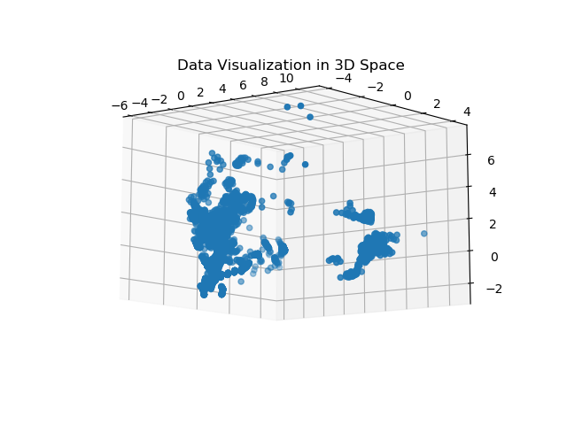

```python
# Visualize data in 3D by projecting data in 3D space using PCA
# prohecting data to 3D space
df_train_PCA, _=l.PCAMahalanobisDistanceOfData(3,df_train_zscale,None)

#2d plot
#plt.scatter(df_PCA[0],df_PCA[1])

#3d plot
fig = plt.figure()
ax = fig.add_subplot(111, projection='3d')
ax.scatter(df_train_PCA[0],df_train_PCA[1],df_train_PCA[2])
plt.title('Data Visualization in 3D Space')
plt.show()
```

```python
########### eliminate features using VIF ########
"""
list_of_selected_features = df_train_zscale.columns.tolist()

new_list_of_selected_features = l.eliminate_feature_using_VIF(df_train_zscale,list_of_selected_features,20)

print(new_list_of_selected_features)
#save correlation matrix of selected features
#df[list_of_selected_features].corr().to_excel('selected_corr.xlsx')
"""
```

I have used three algorithms in order to identify outliers namely PCA+Mahalanobis Distance, KMeans and Autoencoder

I will now one by one explain the the training procedure of the dfferent algorithms, the cluster they formed correponding outliers and the feature importance i.e., feature involved in cluster formation

The first algorithm I have used is PCA+Mahalanobis, second is KMeans and then Autoencoder.

Starting from PCA. I have projected thr data into lower dimension and then used Mahalanobis distance to find ditance between the individual data points (pump readings) and the average of all the readings, higher the distance of data points from average the maximum probability of data point is to be outlier.

The dimension to project data points are calculated by projecting cumulative sum of the variance explained by the dimensions.

# PCA + Mahalanobis Distance

```
Optimum component for PCA
```

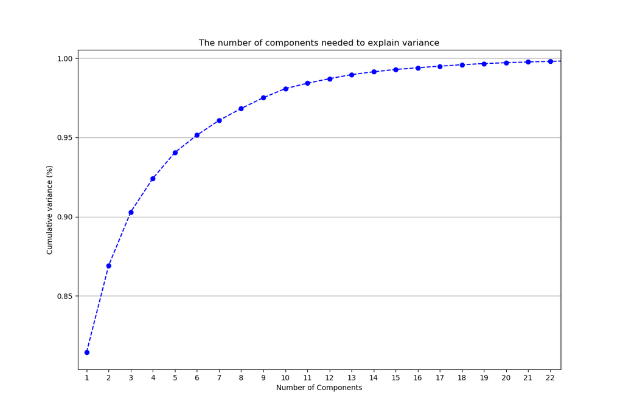

```python
########### PCA + Mahalanobis Distance ################
# get optimum component for PCA
print('Optimum component for PCA')
_ = l.optimum_component_for_PCA(df_train_zscale)
```

From the above graph we can see that approximately 95% of variance in dataset can be explained by n components (eigen vectors corresponding to top 5 eigen values). I have projected the data to these 5 dimensions and proceeded forward to calculate the distance of projected points from mean of the projected points.

```python
## get mahalanobis Distance of vectors in data
df_train_scaled_PCA, df_test_scaled_PCA =l.PCAMahalanobisDistanceOfData(5,df_train_zscale,df_test_zscale)
#df_PCA.to_excel('PCA_Cluster.xlsx')
```

# Histogram plot of Mahalanobis distance of projected Dataset

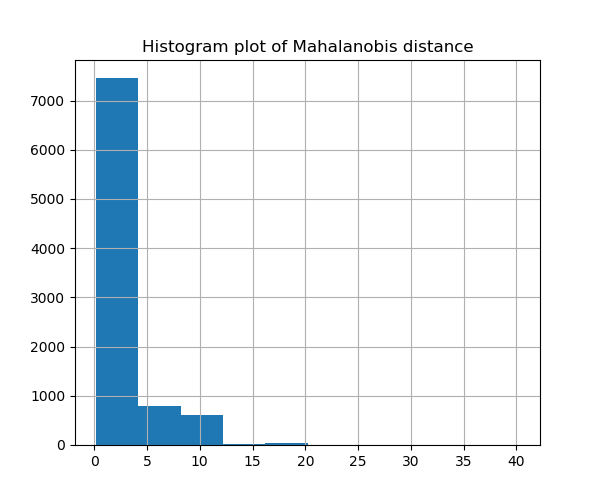

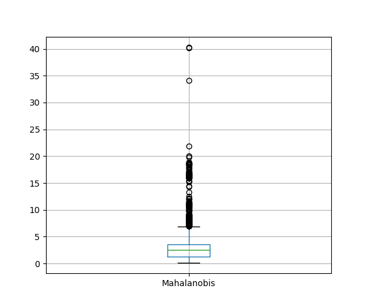

```python
## Histogram plot of Mahalanobis distance
plt.figure(figsize=(6,5))
df_train_PCA['Mahalanobis'].hist()
#plt.xticks(np.arange(0, 26000, step=1000))
#plt.yticks(np.arange(0, 120, step=5))
plt.title('Histogram plot of Mahalanobis distance')
plt.show()

# Boxplot of Mahalanobis distance
plt.figure(figsize=(6,5))
df_train_PCA.boxplot(column = 'Mahalanobis')
plt.show()
```

The output below shows the distribution of the mahalanobis distance of data points from average. The points beyond the threshold distance of 85.07 (3 sigma distance from mean) are considered as outliers.

```python
#mahalanobis distance
df_train_scaled_PCA['Mahalanobis'].describe(percentiles=[0.05,0.10,0.25,0.5,0.75,0.85,0.90,0.95,0.98,0.99,0.997,1.00])
```

```
count    8916.000000
mean        4.999439
std        26.690294
min         0.442038
5%          1.052745
10%         1.596569
25%         2.426590
50%         2.897326
75%         5.506371
85%         7.477814
90%         8.524442
95%         8.911710
98%        11.556305
99%        20.903794
99.7%      31.896519
100%     1105.822589
max      1105.822589
Name: Mahalanobis, dtype: float64
```

## Cluster Profiling

```python
PCA_outlier_threshold = df_train_scaled_PCA['Mahalanobis'].mean()+3*df_train_scaled_PCA['Mahalanobis'].std()


# Cluster Profiling
df_train_PCA = df_train.copy()

df_train_PCA['Anomaly'] = np.where(df_train_scaled_PCA['Mahalanobis']< PCA_outlier_threshold,0,1)
df_train_PCA['Anomaly'].value_counts()

## distance of population mean with clusters
cluster_diff(df_train_PCA, 2, 'Anomaly')

# Feature imporatnce
print("Feature importance\nz")
relative_imp_PCA = Cluster_Profiling(df_train_PCA,'Anomaly')
print("\n{}".format(relative_imp_PCA.T.sort_values(by=1, ascending=False)))
```

```
Number of points in each cluster
Anomaly
0    8907
1       9
dtype: int64


Distance of population mean with clusters
C0: [3.67, 0.0]
C1: [3628.99, 0.04]
Feature importance
z

Anomaly                        0      1
BFPT_B_VALVE_DEMAND_HP_STO -0.00    inf
BFPT_B_VALVE_DEMAND_LP_STO -0.00    inf
BFP_2B_LUBE_OIL_PRESS_____ -0.00  14.39
BFPT_2B_RAD_SHAFT_VIB_IB_B -0.00  10.29
BFP_2B_OBRD_SEAL_INJ_DRN_T -0.00   9.62
BFP_2B_AXIAL_SHAFT_VIB____ -0.00   9.47
2B_BFPT_ROTOR_VIB_IBRB____ -0.00   9.33
BFP_2B_IBRD_SEAL_INJ_DRN_T -0.00   8.57
CW_TO_AUX_CDS_2B           -0.00   8.52
BFP_2B_BARREL_TOP_IBRD_TEM -0.00   5.93
BFP_SUCTION_HDR_TEMP______ -0.00   5.63
BFP_DSCH_HDR_PRESS________ -0.00   5.27
BFP_DISCHARGE_HEADER_TEMP_ -0.00   4.67
BFPT_2B_IN_BRG_MTL_TEMP___ -0.00   3.37
2B_TDBFP_RECIRC_FLOW______ -0.04   3.24
BFP_2B_BARREL_TOP_OBRD_TEM -0.00   2.88
BFP_2B_BARREL_BOT_IBRD_TEM -0.00   2.81
BFP_SEAL_WATER_FLOW        -0.00   2.55
BFP_2B_BARREL_BOT_OBRD_TEM -0.00   2.47
BFP_2B_THRUST_BRG_TEMP____ -0.00   2.43
BFP_2B_RAD_SHAFT_VIB_OB_BR -0.00   2.38
BFP_2B_BAL_DRUM_FLOW______ -0.00   2.36
BFPT_2B_RAD_SHAFT_VIB_OB_B -0.00   2.14
BFPT_B_LP_SPEED_INPUT__2__ -0.00   1.98
BFPT_B_LP_SPEED_INPUT__1__ -0.00   1.97
BFP_2B_RAD_SHAFT_VIB_IB_BR -0.00   1.96
2B_BFPT_ROTOR_VIB_OBRG____ -0.00   1.63
BFP_2B_OUT_BRG_TEMP_______ -0.00   1.59
CW_FRM_AUX_CDSR_2B________ -0.00   1.55
BFPT_2B_THRUST_BRG_DRAIN__ -0.00   1.54
BFPT_2B_AXIAL_SHAFT_VIB___ -0.00   1.50
BFPT_2B_BRG_1_DRAIN_TEMP__ -0.00   1.40
BFP_2B_IN_BRG_TEMP________ -0.00   1.40
2B_TDBFP_RECIRC_VLV_POS___ -0.00   1.19
BFPT_2B_BRG_2_DRAIN_TEMP__ -0.00   1.14
BFPT_B_CALC_VALVE_DEMAND__ -0.00   0.97
BFP_SUCT_HDR_PRESS________ -0.00   0.72
MAIN_STEAM_FLOW_TO_BFPS___ -0.00   0.68
2B_TDBFP_RECIRC_VLV_DMD___ -0.00   0.48
BFPT_2B_FIRST_STAGE_PRESS_ -0.00   0.25
BFPT_2B_THRUST_BRG_WEAR___ -0.00   0.21
EXT_STM_FLOW_TO_BFP_2B____ -0.00   0.01
BFP_2B_OBRD_SEAL_INJ_FLOW_  0.00  -0.31
2B_TDBFP_DISCHARGE_FLOW___  0.00  -0.44
BFP_2B_DISCHARGE_FLOW_____  0.00  -0.47
BFP_2B_IBRD_SEAL_INJ_FLOW_  0.00  -2.52
AUX_CDSR_2B_PRESS_________  0.00 -10.94
Anomaly                      NaN    NaN
```

From the above we can see there are 9 anamolies in the training dataset. Column 1 represents anomalies and the features whose absolute value is greater than 1 are important in forming cluster, further the value from 1 the important the corresponding features.

```python
df_test_PCA = df_test.copy()
df_test_PCA['Anomaly'] = np.where(df_test_scaled_PCA['Mahalanobis']< PCA_outlier_threshold,0,1)
df_test_PCA['Anomaly'].value_counts()
```

```
0    3722
1      11
Name: Anomaly, dtype: int64
```

The algorithm predicts 11 anomalies in test dataset.

# KMeans Algorithm

I have used elbow method to find the Optium number of clusters in the dataset, plotted mean square error for different number clusters formed using KMeans.

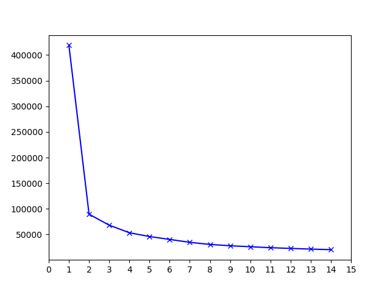

```python
############# KMeans ########################

clusters = range(1,15)

#Sum of squared distances of samples to their closest cluster center.
TSS = []
for i in clusters:
    kmeans = KMeans(n_clusters=i, random_state=0)
    kmeans.fit(df_train_zscale)
    TSS.append(kmeans.inertia_)

plt.plot(clusters,TSS, 'bx-')
plt.xticks(np.arange(0, 16, step=1))
plt.show()
```

```python
df_train_KMeans = df_train.copy()
num_cluster = 7
kmeans = KMeans(n_clusters=num_cluster, random_state=0)
cluster = kmeans.fit_predict(df_train_zscale)
df_train_KMeans['Cluster'] = cluster
#df_KMeans.to_excel('Results/KMeans_cluster.xlsx')
```

## Cluster Profiling

```python
###### Cluster Profiling ############

## distance of population mean with clusters
cluster_diff(df_train_KMeans, num_cluster, 'Cluster')

# Feature imporatnce
Cluster_Profiling(df_train_KMeans, 'Cluster')
```

```
Number of points in each cluster
Cluster
0       8
1    1932
2    2519
3    1863
4    1228
5    1019
6     347
dtype: int64


Distance of population mean with clusters
C0: [3998.03, 0.05]
C1: [2428.43, 0.42]
C2: [6029.62, 0.02]
C3: [2447.84, 0.47]
C4: [2716.0, 0.8]
C5: [2435.83, 0.49]
C6: [2470.39, 0.44]
```

| Cluster | 2B_BFPT_ROTOR_VIB_IBRB____ | 2B_BFPT_ROTOR_VIB_OBRG____ | 2B_TDBFP_DISCHARGE_FLOW___ | 2B_TDBFP_RECIRC_FLOW______ | 2B_TDBFP_RECIRC_VLV_DMD___ | 2B_TDBFP_RECIRC_VLV_POS___ | AUX_CDSR_2B_PRESS_________ | BFPT_2B_AXIAL_SHAFT_VIB___ | BFPT_2B_BRG_1_DRAIN_TEMP__ | BFPT_2B_BRG_2_DRAIN_TEMP__ | ... | BFP_DISCHARGE_HEADER_TEMP_ | BFP_DSCH_HDR_PRESS________ | BFP_SEAL_WATER_FLOW | BFP_SUCTION_HDR_TEMP______ | BFP_SUCT_HDR_PRESS________ | CW_FRM_AUX_CDSR_2B________ | CW_TO_AUX_CDS_2B | Cluster | EXT_STM_FLOW_TO_BFP_2B____ | MAIN_STEAM_FLOW_TO_BFPS___ |
| --- | --- | --- | --- | --- | --- | --- | --- | --- | --- | --- | --- | --- | --- | --- | --- | --- | --- | --- | --- | --- | --- |
| 0 | 8.81 | 1.50 | -0.34 | 4.84 | 0.42 | 1.08 | -11.53 | 2.43 | 1.89 | 1.44 | ... | 4.63 | 5.21 | 2.51 | 5.60 | 0.65 | 1.88 | 8.42 | NaN | 0.14 | 0.82 |
| 1 | -1.16 | -1.56 | -0.52 | -2.43 | inf | 1161.47 | 47.12 | -1.32 | -5.08 | -5.20 | ... | -5.40 | -1.25 | -0.62 | -10.17 | -0.67 | -1.93 | -0.28 | NaN | -529.26 | -0.65 |
| 2 | 21.43 | 10.97 | 7.15 | 1.27 | -208.61 | -70.43 | -27.48 | 5.44 | 14.92 | 13.77 | ... | 23.12 | 15.36 | 0.24 | 23.12 | 4.72 | 4.99 | 2.69 | NaN | 7.52 | -0.44 |
| 3 | -9.35 | -13.43 | -8.03 | -0.13 | inf | 812.42 | 2.70 | -15.11 | -1.64 | -5.30 | ... | -5.21 | -0.82 | 0.46 | -6.11 | -0.59 | 0.03 | 1.52 | NaN | -222.48 | -1.34 |
| 4 | -155.79 | -inf | -inf | -1.37 | inf | 1274.73 | 165.83 | -80.37 | -13.26 | -12.55 | ... | -32.55 | -20.31 | -1.53 | -22.73 | -3.73 | -15.60 | -12.17 | NaN | -inf | 3.44 |
| 5 | -127.13 | -12.67 | -inf | -inf | inf | 1206.61 | 183.25 | -inf | -13.09 | -1.10 | ... | -11.76 | 0.40 | -2.32 | -14.76 | 0.42 | -8.20 | -3.95 | NaN | -inf | -3.22 |
| 6 | -0.68 | -0.87 | -2.43 | 0.33 | 40.91 | 62.01 | -0.40 | -3.62 | -0.26 | -1.23 | ... | 1.79 | 3.20 | 1.25 | 1.99 | 0.87 | 0.42 | 3.19 | NaN | -36.20 | -0.19 |

7 rows × 48 columns

```python
## distance of population mean with clusters
cluster_diff(df_train_KMeans, num_cluster, 'Cluster')
```

```
Number of points in each cluster
Cluster
0       8
1    1932
2    2519
3    1863
4    1228
5    1019
6     347
dtype: int64


Distance of population mean with clusters
C0: [3998.03, 0.05]
C1: [2428.43, 0.42]
C2: [6029.62, 0.02]
C3: [2447.84, 0.47]
C4: [2716.0, 0.8]
C5: [2435.83, 0.49]
C6: [2470.39, 0.44]
```

```python
# Anomaly in training set using KMeans
df_train_KMeans['Anomaly'] = np.where(df_train_KMeans['Cluster']!= 0,0,1)
```

From the above we can see all the clusters are very different from populaton and cluster 0 is the outlier with 8 data points in training set.

```python
# Predict Anomaly by KMEANS
df_test_KMeans = pd.DataFrame(index=df_test.index)
cluster = kmeans.predict(df_test_zscale)
df_test_KMeans['Cluster'] = cluster
df_test_KMeans['Anomaly'] = np.where(df_test_KMeans['Cluster']!= 0,0,1)
df_test_KMeans.groupby('Anomaly').size()
```

```
Anomaly
0    3723
1      10
dtype: int64
```

Test data has 10 outliers. In the last I will compare outliers from all the algorithms.

```python
#df[df['Date'] < df.Date.iloc[0]+timedelta(days=1)].info()
# x = df[df['BFP_SUCT_HDR_PRESS________'].isnull()].index.time
## get date column
#df['Date'] = df.index.date
#df.info()
```

# Autoencoders

I have traind three autoencoders with different nodes and layers and in order to avoid overfitting has scaled the reconstruction error from each of the autoencoder and has aggregated the scaled reconstruction error. Plotted reconstruction error of training dataset, using hit and trial method selected the threshold value of outlier and detected the outliers in both training and test dataset.

## Model 1

(hidden_neurons=[15,15], random_state=42,l2_regularizer=0.0,dropout_rate=0.0)

```python
################ Autoencoders #################
##### Model 1

df_train_ae1 = df_train.copy()

ae1 = AutoEncoder(hidden_neurons=[15,15], random_state=42,l2_regularizer=0.0,dropout_rate=0.0)
ae1.fit(df_train_zscale)
```

```
Model: "sequential_1"
_________________________________________________________________
Layer (type)                 Output Shape              Param #
=================================================================
dense_1 (Dense)              (None, 47)                2256
_________________________________________________________________
dropout_1 (Dropout)          (None, 47)                0
_________________________________________________________________
dense_2 (Dense)              (None, 47)                2256
_________________________________________________________________
dropout_2 (Dropout)          (None, 47)                0
_________________________________________________________________
dense_3 (Dense)              (None, 15)                720
_________________________________________________________________
dropout_3 (Dropout)          (None, 15)                0
_________________________________________________________________
dense_4 (Dense)              (None, 15)                240
_________________________________________________________________
dropout_4 (Dropout)          (None, 15)                0
_________________________________________________________________
dense_5 (Dense)              (None, 47)                752
=================================================================
Total params: 6,224
Trainable params: 6,224
Non-trainable params: 0
_________________________________________________________________
None
Train on 8024 samples, validate on 892 samples
```

```
AutoEncoder(batch_size=32, contamination=0.1, dropout_rate=0.0, epochs=100,
      hidden_activation='relu', hidden_neurons=[15, 15],
      l2_regularizer=0.0,
      loss=<function mean_squared_error at 0x7f0d84d52830>,
      optimizer='adam', output_activation='sigmoid', preprocessing=True,
      random_state=42, validation_size=0.1, verbose=1)
```

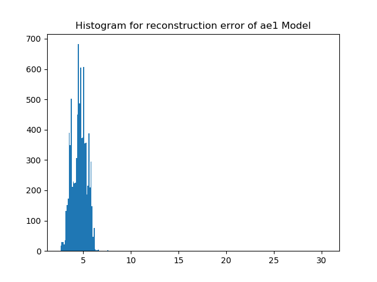

```python
# Get the outlier scores for the train data
y_train_error = ae1.decision_scores_
# Plot reconstruction error
plt.hist(y_train_error, bins='auto')
#sns.kdeplot(y_train_error)
plt.title("Histogram for reconstruction error of ae1 Model")
plt.show()
```

### Cluster Profiling

```python
#Cluster Profiling
df_train_ae1['reconstruction_error']=y_train_error
df_train_ae1['Anomaly']= np.where(y_train_error<=8,0,1)


## print anomaly in train
print("Anomaly in training set \n{}\n\n".format(df_train_ae1.groupby('Anomaly').size()))
#Reconstruction error between clusters
print("Reconstruction error between clusters")
print(df_train_ae1[df_train_ae1['Anomaly']==0]['reconstruction_error'].sum()/sum(df_train_ae1['Anomaly']==0))
print(df_train_ae1[df_train_ae1['Anomaly']==1]['reconstruction_error'].sum()/sum(df_train_ae1['Anomaly']==1))
```

```
Anomaly in training set
Anomaly
0    8905
1      11
dtype: int64


Reconstruction error between clusters
4.62799642326794
21.41058705691862
```

```python
relative_imp_ae1 = Cluster_Profiling(df_train_ae1,'Anomaly')
print(relative_imp_ae1.T.sort_values(by=1, ascending=False))
```

```
Anomaly                        0      1
BFP_2B_LUBE_OIL_PRESS_____ -0.00  16.00
BFPT_2B_RAD_SHAFT_VIB_IB_B -0.00   9.91
CW_TO_AUX_CDS_2B           -0.00   8.36
2B_BFPT_ROTOR_VIB_IBRB____ -0.00   8.12
BFP_2B_OBRD_SEAL_INJ_DRN_T -0.00   7.50
BFP_SUCTION_HDR_TEMP______ -0.00   5.89
BFP_2B_IBRD_SEAL_INJ_DRN_T -0.00   5.87
BFP_2B_BARREL_TOP_IBRD_TEM -0.00   5.63
BFP_DSCH_HDR_PRESS________ -0.00   5.59
BFP_DISCHARGE_HEADER_TEMP_ -0.00   4.94
BFP_2B_AXIAL_SHAFT_VIB____ -0.00   4.66
BFPT_2B_IN_BRG_MTL_TEMP___ -0.00   3.16
BFP_2B_BARREL_TOP_OBRD_TEM -0.00   3.01
BFP_2B_BARREL_BOT_IBRD_TEM -0.00   2.90
BFP_SEAL_WATER_FLOW        -0.00   2.70
BFP_2B_BARREL_BOT_OBRD_TEM -0.00   2.65
BFPT_2B_RAD_SHAFT_VIB_OB_B -0.00   2.20
BFP_2B_THRUST_BRG_TEMP____ -0.00   2.19
BFPT_B_VALVE_DEMAND_HP_STO -0.00   2.06
BFPT_B_VALVE_DEMAND_LP_STO -0.00   2.06
2B_TDBFP_RECIRC_FLOW______ -0.04   1.87
reconstruction_error       -0.03   1.86
2B_BFPT_ROTOR_VIB_OBRG____ -0.00   1.73
BFP_2B_OUT_BRG_TEMP_______ -0.00   1.69
BFPT_2B_AXIAL_SHAFT_VIB___ -0.00   1.66
BFPT_2B_THRUST_BRG_DRAIN__ -0.00   1.64
BFPT_B_LP_SPEED_INPUT__2__ -0.00   1.58
BFPT_B_LP_SPEED_INPUT__1__ -0.00   1.57
BFPT_2B_BRG_1_DRAIN_TEMP__ -0.00   1.54
BFP_2B_BAL_DRUM_FLOW______ -0.00   1.52
BFP_2B_IN_BRG_TEMP________ -0.00   1.49
BFP_2B_RAD_SHAFT_VIB_OB_BR -0.00   1.32
CW_FRM_AUX_CDSR_2B________ -0.00   1.30
BFPT_2B_BRG_2_DRAIN_TEMP__ -0.00   1.29
BFP_2B_RAD_SHAFT_VIB_IB_BR -0.00   1.02
BFP_SUCT_HDR_PRESS________ -0.00   0.87
BFPT_B_CALC_VALVE_DEMAND__ -0.00   0.69
MAIN_STEAM_FLOW_TO_BFPS___ -0.00   0.49
2B_TDBFP_RECIRC_VLV_POS___ -0.00   0.42
BFPT_2B_THRUST_BRG_WEAR___ -0.00   0.29
2B_TDBFP_RECIRC_VLV_DMD___ -0.00   0.24
BFPT_2B_FIRST_STAGE_PRESS_ -0.00   0.01
2B_TDBFP_DISCHARGE_FLOW___  0.00  -0.09
BFP_2B_DISCHARGE_FLOW_____  0.00  -0.10
EXT_STM_FLOW_TO_BFP_2B____  0.00  -0.14
BFP_2B_OBRD_SEAL_INJ_FLOW_  0.00  -0.22
BFP_2B_IBRD_SEAL_INJ_FLOW_  0.00  -2.67
AUX_CDSR_2B_PRESS_________  0.00 -10.89
Anomaly                      NaN    NaN
```

```python
# Predict the anomaly scores
y_test_error = ae1.decision_function(df_test_zscale)  # outlier scores


df_test_ae1 = df_test.copy()
df_test_ae1['Score'] = y_test_error

df_test_ae1['Anomaly'] = np.where(df_test_ae1['Score']<=8,0,1)

#print anomaly in test
print("Anomaly in test\n {}".format(df_test_ae1.groupby('Anomaly').size()))
df_test_ae1.groupby('Anomaly').mean()
```

```
Anomaly in test
 Anomaly
0    3718
1      15
dtype: int64
```

| Anomaly | BFP_SEAL_WATER_FLOW | BFP_SUCT_HDR_PRESS________ | AUX_CDSR_2B_PRESS_________ | BFP_SUCTION_HDR_TEMP______ | BFPT_B_VALVE_DEMAND_HP_STO | BFPT_B_VALVE_DEMAND_LP_STO | BFPT_B_CALC_VALVE_DEMAND__ | 2B_TDBFP_RECIRC_VLV_DMD___ | BFP_2B_DISCHARGE_FLOW_____ | BFP_2B_IBRD_SEAL_INJ_FLOW_ | ... | BFP_2B_AXIAL_SHAFT_VIB____ | BFPT_2B_THRUST_BRG_WEAR___ | BFP_2B_RAD_SHAFT_VIB_OB_BR | BFP_2B_RAD_SHAFT_VIB_IB_BR | BFPT_2B_AXIAL_SHAFT_VIB___ | MAIN_STEAM_FLOW_TO_BFPS___ | EXT_STM_FLOW_TO_BFP_2B____ | CW_FRM_AUX_CDSR_2B________ | CW_TO_AUX_CDS_2B | Score |
| --- | --- | --- | --- | --- | --- | --- | --- | --- | --- | --- | --- | --- | --- | --- | --- | --- | --- | --- | --- | --- | --- |
| 0 | 27.494476 | 150.054766 | 8.578497 | 313.555223 | 24.343776 | 16.813026 | 41.876361 | 18.961068 | 1617.841079 | 7.758034 | ... | 1.679973 | 3.797493 | 0.596173 | 0.662574 | 0.439338 | 0.534088 | 40.886380 | 94.836651 | 82.570627 | 5.017939 |
| 1 | 42.931333 | 127.743238 | 2.812667 | 327.402000 | 30.010000 | 18.006000 | 33.910667 | 64.546000 | 551.463333 | 7.729143 | ... | 1.800667 | -1.100667 | 0.666667 | 0.698000 | 0.488000 | 0.320667 | 15.713333 | 90.546667 | 79.606667 | 23.070620 |

2 rows × 48 columns

## Model 2

(hidden_neurons=[25,10,10,25], dropout_rate = 0.2, l2_regularizer=0.1)

```python
##### Model 2
df_train_ae2 = df_train.copy()

ae2 = AutoEncoder(hidden_neurons=[25,10,10,25], random_state=42)
ae2.fit(df_train_zscale)
```

```
Model: "sequential_3"
_________________________________________________________________
Layer (type)                 Output Shape              Param #
=================================================================
dense_13 (Dense)             (None, 47)                2256
_________________________________________________________________
dropout_11 (Dropout)         (None, 47)                0
_________________________________________________________________
dense_14 (Dense)             (None, 47)                2256
_________________________________________________________________
dropout_12 (Dropout)         (None, 47)                0
_________________________________________________________________
dense_15 (Dense)             (None, 25)                1200
_________________________________________________________________
dropout_13 (Dropout)         (None, 25)                0
_________________________________________________________________
dense_16 (Dense)             (None, 10)                260
_________________________________________________________________
dropout_14 (Dropout)         (None, 10)                0
_________________________________________________________________
dense_17 (Dense)             (None, 10)                110
_________________________________________________________________
dropout_15 (Dropout)         (None, 10)                0
_________________________________________________________________
dense_18 (Dense)             (None, 25)                275
_________________________________________________________________
dropout_16 (Dropout)         (None, 25)                0
_________________________________________________________________
dense_19 (Dense)             (None, 47)                1222
=================================================================
Total params: 7,579
Trainable params: 7,579
Non-trainable params: 0
_________________________________________________________________
None
Train on 8024 samples, validate on 892 samples
```

```
AutoEncoder(batch_size=32, contamination=0.1, dropout_rate=0.2, epochs=100,
      hidden_activation='relu', hidden_neurons=[25, 10, 10, 25],
      l2_regularizer=0.1,
      loss=<function mean_squared_error at 0x7f0d84d52830>,
      optimizer='adam', output_activation='sigmoid', preprocessing=True,
      random_state=42, validation_size=0.1, verbose=1)
```

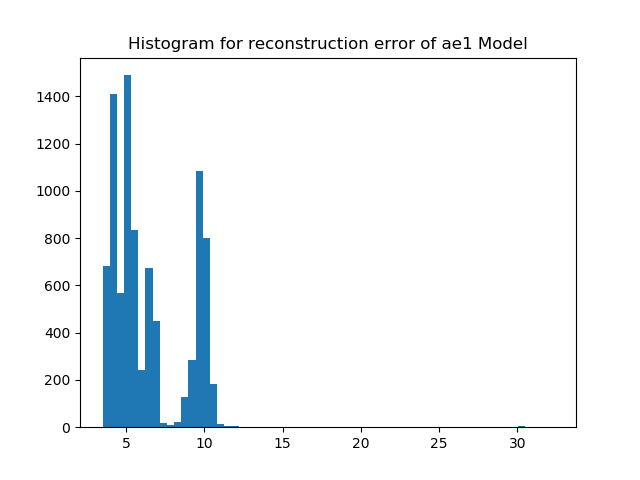

```python
# Get the outlier scores for the train data
y_train_error = ae2.decision_scores_

# Plot reconstruction error
plt.hist(y_train_error, bins='auto')
plt.title("Histogram for reconstruction error of ae1 Model")
plt.show()
```

### Cluster Profiling

```python
#Cluster Profiling
df_train_ae2['reconstruction_error']=y_train_error
df_train_ae2['Anomaly']= np.where(y_train_error<=12.2,0,1)


#print anomaly in train
print("Anomaly in training set \n {}\n\n".format(df_train_ae2.groupby('Anomaly').size()))

#Reconstruction error between clusters
print("Reconstruction error between clusters")
print(df_train_ae2[df_train_ae2['Anomaly']==0]['reconstruction_error'].sum()/sum(df_train_ae2['Anomaly']==0))
print(df_train_ae2[df_train_ae2['Anomaly']==1]['reconstruction_error'].sum()/sum(df_train_ae2['Anomaly']==1))
```

```
Anomaly in training set
 Anomaly
0    8907
1       9
dtype: int64


Reconstruction error between clusters
6.411817343079743
26.30898236010967
```

```python
relative_imp_ae2 = Cluster_Profiling(df_train_ae2,'Anomaly')
print(relative_imp_ae2.T.sort_values(by=1, ascending=False))
```

```
Anomaly                        0      1
BFPT_B_VALVE_DEMAND_HP_STO -0.00    inf
BFPT_B_VALVE_DEMAND_LP_STO -0.00    inf
BFP_2B_LUBE_OIL_PRESS_____ -0.00  14.39
BFPT_2B_RAD_SHAFT_VIB_IB_B -0.00  10.29
BFP_2B_OBRD_SEAL_INJ_DRN_T -0.00   9.62
BFP_2B_AXIAL_SHAFT_VIB____ -0.00   9.47
2B_BFPT_ROTOR_VIB_IBRB____ -0.00   9.33
BFP_2B_IBRD_SEAL_INJ_DRN_T -0.00   8.57
CW_TO_AUX_CDS_2B           -0.00   8.52
BFP_2B_BARREL_TOP_IBRD_TEM -0.00   5.93
BFP_SUCTION_HDR_TEMP______ -0.00   5.63
BFP_DSCH_HDR_PRESS________ -0.00   5.27
BFP_DISCHARGE_HEADER_TEMP_ -0.00   4.67
BFPT_2B_IN_BRG_MTL_TEMP___ -0.00   3.37
2B_TDBFP_RECIRC_FLOW______ -0.04   3.24
reconstruction_error       -0.01   2.96
BFP_2B_BARREL_TOP_OBRD_TEM -0.00   2.88
BFP_2B_BARREL_BOT_IBRD_TEM -0.00   2.81
BFP_SEAL_WATER_FLOW        -0.00   2.55
BFP_2B_BARREL_BOT_OBRD_TEM -0.00   2.47
BFP_2B_THRUST_BRG_TEMP____ -0.00   2.43
BFP_2B_RAD_SHAFT_VIB_OB_BR -0.00   2.38
BFP_2B_BAL_DRUM_FLOW______ -0.00   2.36
BFPT_2B_RAD_SHAFT_VIB_OB_B -0.00   2.14
BFPT_B_LP_SPEED_INPUT__2__ -0.00   1.98
BFPT_B_LP_SPEED_INPUT__1__ -0.00   1.97
BFP_2B_RAD_SHAFT_VIB_IB_BR -0.00   1.96
2B_BFPT_ROTOR_VIB_OBRG____ -0.00   1.63
BFP_2B_OUT_BRG_TEMP_______ -0.00   1.59
CW_FRM_AUX_CDSR_2B________ -0.00   1.55
BFPT_2B_THRUST_BRG_DRAIN__ -0.00   1.54
BFPT_2B_AXIAL_SHAFT_VIB___ -0.00   1.50
BFPT_2B_BRG_1_DRAIN_TEMP__ -0.00   1.40
BFP_2B_IN_BRG_TEMP________ -0.00   1.40
2B_TDBFP_RECIRC_VLV_POS___ -0.00   1.19
BFPT_2B_BRG_2_DRAIN_TEMP__ -0.00   1.14
BFPT_B_CALC_VALVE_DEMAND__ -0.00   0.97
BFP_SUCT_HDR_PRESS________ -0.00   0.72
MAIN_STEAM_FLOW_TO_BFPS___ -0.00   0.68
2B_TDBFP_RECIRC_VLV_DMD___ -0.00   0.48
BFPT_2B_FIRST_STAGE_PRESS_ -0.00   0.25
BFPT_2B_THRUST_BRG_WEAR___ -0.00   0.21
EXT_STM_FLOW_TO_BFP_2B____ -0.00   0.01
BFP_2B_OBRD_SEAL_INJ_FLOW_  0.00  -0.31
2B_TDBFP_DISCHARGE_FLOW___  0.00  -0.44
BFP_2B_DISCHARGE_FLOW_____  0.00  -0.47
BFP_2B_IBRD_SEAL_INJ_FLOW_  0.00  -2.52
AUX_CDSR_2B_PRESS_________  0.00 -10.94
Anomaly                      NaN    NaN
```

```python
# Predict the anomaly scores
y_test_error = ae2.decision_function(df_test_zscale)  # outlier scores
df_test_ae2 = df_test.copy()
df_test_ae2.loc[:,'Score'] = y_test_error
df_test_ae2['Anomaly'] = np.where(df_test_ae2['Score']<=12.2,0,1)


#print anomaly in test
print("Anomaly in test {}".format(df_test_ae2.groupby('Anomaly').size()))
df_test_ae2.groupby('Anomaly').mean()
```

```
Anomaly in test Anomaly
0    3721
1      12
dtype: int64
```

| Anomaly | BFP_SEAL_WATER_FLOW | BFP_SUCT_HDR_PRESS________ | AUX_CDSR_2B_PRESS_________ | BFP_SUCTION_HDR_TEMP______ | BFPT_B_VALVE_DEMAND_HP_STO | BFPT_B_VALVE_DEMAND_LP_STO | BFPT_B_CALC_VALVE_DEMAND__ | 2B_TDBFP_RECIRC_VLV_DMD___ | BFP_2B_DISCHARGE_FLOW_____ | BFP_2B_IBRD_SEAL_INJ_FLOW_ | ... | BFP_2B_AXIAL_SHAFT_VIB____ | BFPT_2B_THRUST_BRG_WEAR___ | BFP_2B_RAD_SHAFT_VIB_OB_BR | BFP_2B_RAD_SHAFT_VIB_IB_BR | BFPT_2B_AXIAL_SHAFT_VIB___ | MAIN_STEAM_FLOW_TO_BFPS___ | EXT_STM_FLOW_TO_BFP_2B____ | CW_FRM_AUX_CDSR_2B________ | CW_TO_AUX_CDS_2B | Score |
| --- | --- | --- | --- | --- | --- | --- | --- | --- | --- | --- | --- | --- | --- | --- | --- | --- | --- | --- | --- | --- | --- |
| 0 | 27.509594 | 150.027342 | 8.572658 | 313.562204 | 24.348345 | 16.807536 | 41.859524 | 19.025189 | 1616.543416 | 7.758651 | ... | 1.679664 | 3.789132 | 0.596015 | 0.662217 | 0.439100 | 0.533381 | 40.834066 | 94.825458 | 82.566224 | 9.133915 |
| 1 | 42.102500 | 130.669286 | 3.181667 | 328.699167 | 30.010000 | 20.006667 | 37.140000 | 56.059167 | 687.252500 | 7.530595 | ... | 1.926667 | 0.267500 | 0.733333 | 0.817500 | 0.574167 | 0.486667 | 25.641667 | 92.945000 | 80.230833 | 28.739276 |

2 rows × 48 columns

## Model 3

(hidden_neurons=[25,10,6,10,25], dropout_rate = 0.2, l2_regularizer=0.1)

```python
## Model 3

# dataframe for train set
df_train_ae3 = df_train.copy()

ae3 = AutoEncoder(hidden_neurons=[25,10,6,10,25],random_state=42)
ae3.fit(df_train_zscale)
```

```
Model: "sequential_4"
_________________________________________________________________
Layer (type)                 Output Shape              Param #
=================================================================
dense_20 (Dense)             (None, 47)                2256
_________________________________________________________________
dropout_17 (Dropout)         (None, 47)                0
_________________________________________________________________
dense_21 (Dense)             (None, 47)                2256
_________________________________________________________________
dropout_18 (Dropout)         (None, 47)                0
_________________________________________________________________
dense_22 (Dense)             (None, 25)                1200
_________________________________________________________________
dropout_19 (Dropout)         (None, 25)                0
_________________________________________________________________
dense_23 (Dense)             (None, 10)                260
_________________________________________________________________
dropout_20 (Dropout)         (None, 10)                0
_________________________________________________________________
dense_24 (Dense)             (None, 6)                 66
_________________________________________________________________
dropout_21 (Dropout)         (None, 6)                 0
_________________________________________________________________
dense_25 (Dense)             (None, 10)                70
_________________________________________________________________
dropout_22 (Dropout)         (None, 10)                0
_________________________________________________________________
dense_26 (Dense)             (None, 25)                275
_________________________________________________________________
dropout_23 (Dropout)         (None, 25)                0
_________________________________________________________________
dense_27 (Dense)             (None, 47)                1222
=================================================================
Total params: 7,605
Trainable params: 7,605
Non-trainable params: 0
_________________________________________________________________
None
Train on 8024 samples, validate on 892 samples
```

```
AutoEncoder(batch_size=32, contamination=0.1, dropout_rate=0.2, epochs=100,
      hidden_activation='relu', hidden_neurons=[25, 10, 6, 10, 25],
      l2_regularizer=0.1,
      loss=<function mean_squared_error at 0x7f0d84d52830>,
      optimizer='adam', output_activation='sigmoid', preprocessing=True,
      random_state=42, validation_size=0.1, verbose=1)
```

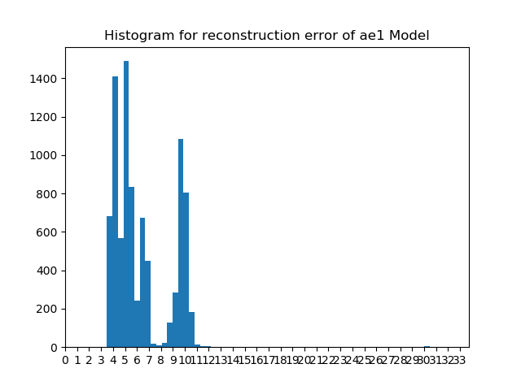

```python
y_train_error = ae3.decision_scores_
# Plot reconstruction error
plt.hist(pd.Series(y_train_error), bins='auto')
plt.xticks(np.arange(0,34,1))
plt.title("Histogram for reconstruction error of ae1 Model")
plt.show()
```

### Cluster Profiling

```python
#Cluster Profiling
df_train_ae3['reconstruction_error']=y_train_error
df_train_ae3['Anomaly']= np.where(y_train_error<=13.2,0,1)


## print anomaly in training set
print("anomaly in training set\n {} \n\n".format(df_train_ae3.groupby('Anomaly').size()))
#Reconstruction error between clusters
print("Reconstruction error between clusters")
print(df_train_ae3[df_train_ae3['Anomaly']==0]['reconstruction_error'].sum()/sum(df_train_ae3['Anomaly']==0))
print(df_train_ae3[df_train_ae3['Anomaly']==1]['reconstruction_error'].sum()/sum(df_train_ae3['Anomaly']==1))
```

```
anomaly in training set
 Anomaly
0    8908
1       8
dtype: int64


Reconstruction error between clusters
6.412521534624451
27.998864813960417
```

```python
relative_imp_ae3 = Cluster_Profiling(df_train_ae3,'Anomaly')
```

```python
print(relative_imp_ae3.T.sort_values(by=1, ascending=False))
```

```
Anomaly                        0      1
BFPT_B_VALVE_DEMAND_HP_STO -0.00    inf
BFPT_B_VALVE_DEMAND_LP_STO -0.00    inf
BFP_2B_LUBE_OIL_PRESS_____ -0.00  17.82
BFP_2B_AXIAL_SHAFT_VIB____ -0.00  10.76
BFPT_2B_RAD_SHAFT_VIB_IB_B -0.00   9.66
BFP_2B_OBRD_SEAL_INJ_DRN_T -0.00   9.01
2B_BFPT_ROTOR_VIB_IBRB____ -0.00   8.81
CW_TO_AUX_CDS_2B           -0.00   8.42
BFP_2B_IBRD_SEAL_INJ_DRN_T -0.00   8.04
BFP_2B_BARREL_TOP_IBRD_TEM -0.00   5.75
BFP_SUCTION_HDR_TEMP______ -0.00   5.60
BFPT_2B_IN_BRG_MTL_TEMP___ -0.00   5.24
BFP_DSCH_HDR_PRESS________ -0.00   5.21
2B_TDBFP_RECIRC_FLOW______ -0.04   4.84
BFP_DISCHARGE_HEADER_TEMP_ -0.00   4.63
reconstruction_error       -0.01   4.58
BFP_2B_BAL_DRUM_FLOW______ -0.00   3.78
BFP_2B_THRUST_BRG_TEMP____ -0.00   3.17
BFPT_B_LP_SPEED_INPUT__1__ -0.00   2.87
BFPT_B_LP_SPEED_INPUT__2__ -0.00   2.85
BFP_2B_BARREL_TOP_OBRD_TEM -0.00   2.77
BFP_2B_BARREL_BOT_IBRD_TEM -0.00   2.67
BFP_SEAL_WATER_FLOW        -0.00   2.51
BFPT_2B_AXIAL_SHAFT_VIB___ -0.00   2.43
BFP_2B_BARREL_BOT_OBRD_TEM -0.00   2.37
BFP_2B_RAD_SHAFT_VIB_OB_BR -0.00   2.35
BFP_2B_RAD_SHAFT_VIB_IB_BR -0.00   2.32
BFPT_2B_THRUST_BRG_DRAIN__ -0.00   2.11
BFPT_2B_RAD_SHAFT_VIB_OB_B -0.00   2.02
BFPT_2B_BRG_1_DRAIN_TEMP__ -0.00   1.89
CW_FRM_AUX_CDSR_2B________ -0.00   1.88
BFP_2B_OUT_BRG_TEMP_______ -0.00   1.86
BFP_2B_IN_BRG_TEMP________ -0.00   1.56
2B_BFPT_ROTOR_VIB_OBRG____ -0.00   1.50
BFPT_2B_BRG_2_DRAIN_TEMP__ -0.00   1.44
BFPT_B_CALC_VALVE_DEMAND__ -0.00   1.23
2B_TDBFP_RECIRC_VLV_POS___ -0.00   1.08
MAIN_STEAM_FLOW_TO_BFPS___ -0.00   0.82
BFP_SUCT_HDR_PRESS________ -0.00   0.65
BFPT_2B_FIRST_STAGE_PRESS_ -0.00   0.49
2B_TDBFP_RECIRC_VLV_DMD___ -0.00   0.42
BFPT_2B_THRUST_BRG_WEAR___ -0.00   0.19
EXT_STM_FLOW_TO_BFP_2B____ -0.00   0.14
2B_TDBFP_DISCHARGE_FLOW___  0.00  -0.34
BFP_2B_DISCHARGE_FLOW_____  0.00  -0.37
BFP_2B_OBRD_SEAL_INJ_FLOW_  0.00  -0.64
BFP_2B_IBRD_SEAL_INJ_FLOW_  0.00  -2.63
AUX_CDSR_2B_PRESS_________  0.00 -11.53
Anomaly                      NaN    NaN
```

```python
# Predict the anomaly scores
y_test_error = ae3.decision_function(df_test_zscale)  # outlier scores
df_test_ae3 = df_test.copy()
df_test_ae3['Score'] = y_test_error
df_test_ae3['Anomaly'] = np.where(df_test_ae3['Score']<=13.2,0,1)


#print anomaly in test
print("Anomaly in test {}".format(df_test_ae3.groupby('Anomaly').size()))
df_test_ae3.groupby('Anomaly').mean()
```

```
Anomaly in test Anomaly
0    3722
1      11
dtype: int64
```

| Anomaly | BFP_SEAL_WATER_FLOW | BFP_SUCT_HDR_PRESS________ | AUX_CDSR_2B_PRESS_________ | BFP_SUCTION_HDR_TEMP______ | BFPT_B_VALVE_DEMAND_HP_STO | BFPT_B_VALVE_DEMAND_LP_STO | BFPT_B_CALC_VALVE_DEMAND__ | 2B_TDBFP_RECIRC_VLV_DMD___ | BFP_2B_DISCHARGE_FLOW_____ | BFP_2B_IBRD_SEAL_INJ_FLOW_ | ... | BFP_2B_AXIAL_SHAFT_VIB____ | BFPT_2B_THRUST_BRG_WEAR___ | BFP_2B_RAD_SHAFT_VIB_OB_BR | BFP_2B_RAD_SHAFT_VIB_IB_BR | BFPT_2B_AXIAL_SHAFT_VIB___ | MAIN_STEAM_FLOW_TO_BFPS___ | EXT_STM_FLOW_TO_BFP_2B____ | CW_FRM_AUX_CDSR_2B________ | CW_TO_AUX_CDS_2B | Score |
| --- | --- | --- | --- | --- | --- | --- | --- | --- | --- | --- | --- | --- | --- | --- | --- | --- | --- | --- | --- | --- | --- |
| 0 | 27.511193 | 150.037044 | 8.571687 | 313.570430 | 24.349866 | 16.811083 | 41.860973 | 19.020723 | 1616.702512 | 7.758527 | ... | 1.679718 | 3.789922 | 0.596048 | 0.662270 | 0.439285 | 0.533657 | 40.844334 | 94.827620 | 82.566566 | 9.134886 |
| 1 | 42.888182 | 125.626494 | 3.020000 | 327.291818 | 30.010000 | 19.097273 | 36.220909 | 60.937273 | 548.939091 | 7.551948 | ... | 1.930909 | -0.320000 | 0.734545 | 0.813636 | 0.523636 | 0.389091 | 20.786364 | 92.042727 | 79.902727 | 30.203300 |

2 rows × 48 columns

## Aggregate all the three model of Autoencoder

```python
from pyod.models.combination import average as avg

# Put all the predictions in a data frame
train_scores = pd.DataFrame({'ae1': ae1.decision_scores_,
                             'ae2': ae2.decision_scores_,
                             'ae3': ae3.decision_scores_
                            })

test_scores  = pd.DataFrame({'ae1': ae1.decision_function(df_test_zscale),
                             'ae2': ae2.decision_function(df_test_zscale),
                             'ae3': ae3.decision_function(df_test_zscale)
                            })
```

```python
# normalise train, test scores
scaler = StandardScaler()
scaler.fit(train_scores)
train_scores_zscale = pd.DataFrame(scaler.transform(train_scores), columns = train_scores.columns, index = train_scores.index)
test_scores_zscale = pd.DataFrame(scaler.transform(test_scores), columns = test_scores.columns, index = test_scores.index)
```

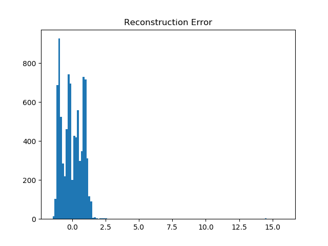

```python
# Combination by average
%matplotlib notebook
train_scores_by_average = avg(train_scores_zscale)

plt.hist(train_scores_by_average, bins='auto')  # arguments are passed to np.histogram
plt.title("Reconstruction Error")
plt.show()
```

## Cluster Profiling

```python
# Cluster Profiling
df_train_ae = df_train.copy()
df_train_ae['train_scores_by_average'] = train_scores_by_average
df_train_ae['Anomaly'] = np.where(df_train_ae['train_scores_by_average']<3.7, 0, 1)
df_train_ae['Anomaly'].value_counts()



#print anomaly in train
print("Anomaly in train \n{}\n\n".format(df_train_ae['Anomaly'].value_counts()))
#feature importance
relative_imp_ae = Cluster_Profiling(df_train_ae,'Anomaly')
print(relative_imp_ae.T.sort_values(by=1, ascending=False))
```

```
Anomaly in train
0    8908
1       8
Name: Anomaly, dtype: int64


Anomaly                        0      1
BFPT_B_VALVE_DEMAND_HP_STO -0.00    inf
BFPT_B_VALVE_DEMAND_LP_STO -0.00    inf
BFP_2B_LUBE_OIL_PRESS_____ -0.00  17.82
BFP_2B_AXIAL_SHAFT_VIB____ -0.00  10.76
BFPT_2B_RAD_SHAFT_VIB_IB_B -0.00   9.66
BFP_2B_OBRD_SEAL_INJ_DRN_T -0.00   9.01
2B_BFPT_ROTOR_VIB_IBRB____ -0.00   8.81
CW_TO_AUX_CDS_2B           -0.00   8.42
BFP_2B_IBRD_SEAL_INJ_DRN_T -0.00   8.04
BFP_2B_BARREL_TOP_IBRD_TEM -0.00   5.75
BFP_SUCTION_HDR_TEMP______ -0.00   5.60
BFPT_2B_IN_BRG_MTL_TEMP___ -0.00   5.24
BFP_DSCH_HDR_PRESS________ -0.00   5.21
2B_TDBFP_RECIRC_FLOW______ -0.04   4.84
BFP_DISCHARGE_HEADER_TEMP_ -0.00   4.63
train_scores_by_average    -0.02   4.48
BFP_2B_BAL_DRUM_FLOW______ -0.00   3.78
BFP_2B_THRUST_BRG_TEMP____ -0.00   3.17
BFPT_B_LP_SPEED_INPUT__1__ -0.00   2.87
BFPT_B_LP_SPEED_INPUT__2__ -0.00   2.85
BFP_2B_BARREL_TOP_OBRD_TEM -0.00   2.77
BFP_2B_BARREL_BOT_IBRD_TEM -0.00   2.67
BFP_SEAL_WATER_FLOW        -0.00   2.51
BFPT_2B_AXIAL_SHAFT_VIB___ -0.00   2.43
BFP_2B_BARREL_BOT_OBRD_TEM -0.00   2.37
BFP_2B_RAD_SHAFT_VIB_OB_BR -0.00   2.35
BFP_2B_RAD_SHAFT_VIB_IB_BR -0.00   2.32
BFPT_2B_THRUST_BRG_DRAIN__ -0.00   2.11
BFPT_2B_RAD_SHAFT_VIB_OB_B -0.00   2.02
BFPT_2B_BRG_1_DRAIN_TEMP__ -0.00   1.89
CW_FRM_AUX_CDSR_2B________ -0.00   1.88
BFP_2B_OUT_BRG_TEMP_______ -0.00   1.86
BFP_2B_IN_BRG_TEMP________ -0.00   1.56
2B_BFPT_ROTOR_VIB_OBRG____ -0.00   1.50
BFPT_2B_BRG_2_DRAIN_TEMP__ -0.00   1.44
BFPT_B_CALC_VALVE_DEMAND__ -0.00   1.23
2B_TDBFP_RECIRC_VLV_POS___ -0.00   1.08
MAIN_STEAM_FLOW_TO_BFPS___ -0.00   0.82
BFP_SUCT_HDR_PRESS________ -0.00   0.65
BFPT_2B_FIRST_STAGE_PRESS_ -0.00   0.49
2B_TDBFP_RECIRC_VLV_DMD___ -0.00   0.42
BFPT_2B_THRUST_BRG_WEAR___ -0.00   0.19
EXT_STM_FLOW_TO_BFP_2B____ -0.00   0.14
2B_TDBFP_DISCHARGE_FLOW___  0.00  -0.34
BFP_2B_DISCHARGE_FLOW_____  0.00  -0.37
BFP_2B_OBRD_SEAL_INJ_FLOW_  0.00  -0.64
BFP_2B_IBRD_SEAL_INJ_FLOW_  0.00  -2.63
AUX_CDSR_2B_PRESS_________  0.00 -11.53
Anomaly                      NaN    NaN
```

```python
df_test_ae = df_test.copy()
df_test_ae['test_scores_by_average'] = avg(test_scores_zscale)
df_test_ae['Anomaly'] = np.where(df_test_ae['test_scores_by_average']<3.7, 0, 1)
df_test_ae['Anomaly'].value_counts()
```

```
0    3722
1      11
Name: Anomaly, dtype: int64
```

# Prediction of anomalies from all the algorithm

1. From training set

```python
#Training Set
df_train['PCA_Anomaly'] = df_train_PCA['Anomaly']
df_train['KMeans_Anomaly'] = df_train_KMeans['Anomaly']
df_train['AE_Anomaly'] = df_train_ae['Anomaly']


print('Anomalies from different algorithms in training set')
print(df_train.groupby(['AE_Anomaly','PCA_Anomaly','KMeans_Anomaly']).size())


# Anomaly from 3 algorithm
df_train['Anomaly'] = np.where((df_train['AE_Anomaly']==1) & (df_train['PCA_Anomaly']==1) & (df_train['KMeans_Anomaly']==1),1,0)
print(df_train[df_train['Anomaly']==1].index)
```

```
Anomalies from different algorithms in training set
AE_Anomaly  PCA_Anomaly  KMeans_Anomaly
0           0            0                 8907
            1            0                    1
1           1            1                    8
dtype: int64
DatetimeIndex(['1998-05-23 02:00:00', '1998-05-23 02:05:00',
               '1998-05-23 02:10:00', '1998-05-23 02:15:00',
               '1998-05-23 02:20:00', '1998-05-26 23:40:00',
               '1998-05-27 03:10:00', '1998-05-27 03:15:00'],
              dtype='datetime64[ns]', freq=None)
```

1. From test set

```python
################## Prediction of anomalies from all the algorithm ##############

df_test['PCA_Anomaly'] = df_test_PCA['Anomaly']
df_test['KMeans_Anomaly'] = df_test_KMeans['Anomaly']
df_test['AE_Anomaly'] = df_test_ae['Anomaly']

print('Anomalies from different algorithms in test set')
print(df_test.groupby(['AE_Anomaly','PCA_Anomaly','KMeans_Anomaly']).size())


# Anomaly from 3 algorithm
df_test['Anomaly'] = np.where((df_test['AE_Anomaly']==1) & (df_test['PCA_Anomaly']==1) & (df_test['KMeans_Anomaly']==1),1,0)
print(df_test[df_test['Anomaly']==1].index)
```

```
Anomalies from different algorithms in test set
AE_Anomaly  PCA_Anomaly  KMeans_Anomaly
0           0            0                 3721
            1            0                    1
1           0            0                    1
            1            1                   10
dtype: int64
DatetimeIndex(['1998-06-07 06:40:00', '1998-06-07 06:45:00',
               '1998-06-07 12:55:00', '1998-06-07 13:00:00',
               '1998-06-07 13:05:00', '1998-06-08 07:45:00',
               '1998-06-09 20:30:00', '1998-06-09 20:35:00',
               '1998-06-09 20:40:00', '1998-06-09 20:45:00'],
              dtype='datetime64[ns]', freq=None)
```

From the above we can see that all the algorithm has captured 18 datapoint as outlier that are from days 23rd May, 26th May, 27th May, 7th June, 8th June and 9th June.